# STAT 240 Discussion 9

## Group 333:B (use the assigned group name/number)

Tony Chen, Clare Bradley, TYLER GEE, ALAN LUO, ASEEM SHARMA

## Introduction

In this report, our group focused on the trend of water temperature from 2014 to 2017 in the Lake Michigan beachfront of Chicago. Since climate change has been posing an increasingly challenging risk to the planet, we want to observe how a specific body of water has been affected in a few short years, and how temperature correlates to other variables in the lake. We believe that water average temperature will increase from 2014 to 2017, and it will change the other variables studied.

## Background Section:

Chicago is located in the Midwest of the United States, on the Lake Michigan lakefront, along this area, there are beaches, parks and other attractions. Water temperature is a physical property expressing how hot or cold water is, and rapid temperature increase in Lake Michigan might have an adverse effect on aspects of the lake. A general consensus among climate scientists is that average temperature of the Earth is changing, but this might vary in different areas and different ecosystems. In this report, we are going to focus on how water temperature correlates to aspects of Lake Michigan, as well as the trends between independent variables overtime. We examine hourly records to find trends and correlations over time. Beach Water Quality records date back to May 15, 2014, and continue to be updated presently, seemingly on a yearly basis. The Beach Water Quality dataset has been collected by the Chicago Park District, maintaining sensors in the water at beaches along Chicago’s Lake Michigan lakefront. Sensor locations change from time to time, though, due to the Park District’s operational needs (mainly water quality). Further, during some seasons and at some times, information from the sensors may not be available. As such, we chose not to include 2013 in our set, as there wasn’t enough data present to make any significant conclusions. Other significant variables of interest are beach name, water temperature, turbidity, wave height, and wave period. We will use all of the other variables in order to observe any trends from beach to beach, allowing us to make significant conclusions if the data follows similar trends despite occurring at different locations. We will use the water temperature (measured in Celsius), turbidity (a measurement of how cloudy the water is), the height of the wave, and the period (distance between the waves) of the wave, in order to make observations about each beach, as well as any changes that take place as hours, seasons, and years pass.

Key Variables from the Beach Water Quality dataset

| Name | Description |
| --- | --- |
| beach | Name of the beach data is collected at |
| time | Time the data was collected at |
| temp | Temperature of the water |
| turbidity | Turbidity (cloudiness) of the water |
| wave_height | Height of the waves (measured in meters) |
| wave_period | Period (distance between peaks) of the waves (measured in meters |

```r
#read and rename data
beach = read_csv("../../data/bwq.csv")

beach = beach %>% rename(date = `Measurement Timestamp`, beach_name = `Beach Name`, water_temp = `Water Temperature`, trans_depth = `Transducer Depth`, wave_height = `Wave Height`, wave_period = `Wave Period`, battery_life = `Battery Life`, turbidity = Turbidity)

beach
```

```
## # A tibble: 34,923 × 8
##    beach_name   date    water_temp turbidity trans_depth wave_height wave_period
##    <chr>        <chr>        <dbl>     <dbl>       <dbl>       <dbl>       <dbl>
##  1 Montrose Be… 08/30/…       20.3      1.18       0.891       0.08            3
##  2 Ohio Street… 05/26/…       14.4      1.23      NA           0.111           4
##  3 Calumet Bea… 09/03/…       23.2      3.63       1.20        0.174           6
##  4 Calumet Bea… 05/28/…       16.2      1.26       1.51        0.147           4
##  5 Montrose Be… 05/28/…       14.4      3.36       1.39        0.298           4
##  6 Montrose Be… 05/28/…       14.5      2.72       1.40        0.306           3
##  7 Calumet Bea… 05/28/…       16.3      1.28       1.52        0.162           4
##  8 Montrose Be… 05/28/…       14.8      2.97       1.39        0.328           3
##  9 Calumet Bea… 05/28/…       16.5      1.32       1.54        0.185           4
## 10 Calumet Bea… 05/28/…       16.8      1.31       1.57        0.196           4
## # … with 34,913 more rows, and 1 more variable: battery_life <dbl>
```

```r
#seperate the date column into date and time column

beach1 = beach %>% mutate(date_mdy = str_match(date, "\\d+.\\d+.\\d+")) %>% mutate(time = str_match(date, "\\s.+")) %>% mutate(date = mdy(date_mdy)) %>% select(-date_mdy) %>% filter(!(wave_height < 0)) %>% filter(!(wave_period < 0)) %>% filter(!(water_temp == 0)) %>%  mutate(year = year(date), month = month(date), day = day(date)) %>% filter(!(year == 2013)) %>% filter(beach_name == "Ohio Street Beach") %>% filter(!(month == 5)) %>% select(-trans_depth) %>% drop_na() %>% select(beach_name, year, month, day ,water_temp, wave_period, wave_height, turbidity)
beach1
```

```
## # A tibble: 8,850 × 8
##    beach_name         year month   day water_temp wave_period wave_height turbidity
##    <chr>             <dbl> <dbl> <int>      <dbl>       <dbl>       <dbl>     <dbl>
##  1 Ohio Street Beach  2014     6     5       16.9           3       0.159      1.6
##  2 Ohio Street Beach  2014     6     6       18.8           2       0.135      0.7
##  3 Ohio Street Beach  2014     6     6       19.8           3       0.162      0.78
##  4 Ohio Street Beach  2014     6     6       19.7           3       0.13       0.77
##  5 Ohio Street Beach  2014     6     6       19.2           2       0.137      0.8
##  6 Ohio Street Beach  2014     6     6       18.7           2       0.147      1.03
##  7 Ohio Street Beach  2014     6     6       18.1           2       0.144      0.83
##  8 Ohio Street Beach  2014     6     6       17.3           2       0.133      1
##  9 Ohio Street Beach  2014     6     6       17.1           3       0.119      1.12
## 10 Ohio Street Beach  2014     6     7       16.8           3       0.127      1.21
## # … with 8,840 more rows
```

## Graph One

```r
beach3 = beach1 %>% group_by(year) %>% summarize(water_temp = mean(water_temp))
```

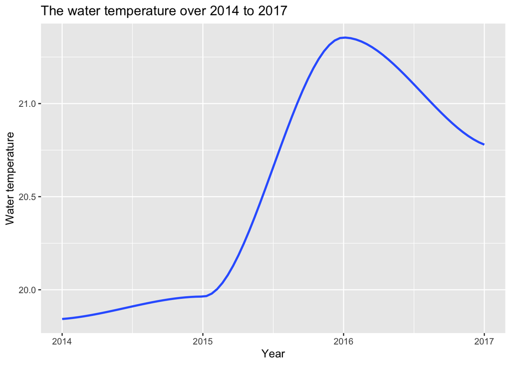

```r
beach3 %>% ggplot(aes(x = year, y = water_temp))+
  geom_smooth(se = FALSE) +
  ggtitle("The water temperature over 2014 to 2017") +
  xlab("Year") +
  ylab("Water temperature")
```

## Two Sided T Test Against the water temperature mean in 2014 and 2017:

Test the hypothesis that the mean water temperature are equal in 2014 and 2017 versus the two-sided alternative that they are not.

1. Define parameters and a model

Xi∼F1(μ1,σ1) Yi∼F2(μ2,σ2)

2. State hypotheses

Null Hypothesis H0:μ1=μ2 Alternative Hypothesis Ha:μ1≠μ2

```r
beach_analysis = beach1 %>% filter(year == 2014 | year == 2017) %>% group_by(year) %>% summarize(n = n(), water_temp_avg = mean(water_temp), std = sd(water_temp), se = std/sqrt(n)) %>% mutate(t.975 = qt(.975, n-1)) %>% mutate(lower = water_temp_avg - t.975*se) %>% mutate(high = water_temp_avg + t.975*se)
#mutate(std = sd(water_temp)) %>% select(water_temp, std)

beach_analysis
```

```
## # A tibble: 2 × 8
##    year     n water_temp_avg   std     se t.975 lower  high
##   <dbl> <int>          <dbl> <dbl>  <dbl> <dbl> <dbl> <dbl>
## 1  2014  2002           19.8  2.51 0.0560  1.96  19.7  20.0
## 2  2017  2397           20.8  2.58 0.0527  1.96  20.7  20.9
```

### Interpreatation:

```r
beach_2014_mean = beach1 %>% filter(year == 2014) %>% pull(water_temp)
beach_2017_mean = beach1 %>% filter(year == 2017) %>% pull(water_temp)
t.test(beach_2014_mean, beach_2017_mean)
```

```
##
##  Welch Two Sample t-test
##
## data:  beach_2014_mean and beach_2017_mean
## t = -12.171, df = 4298.7, p-value < 2.2e-16
## alternative hypothesis: true difference in means is not equal to 0
## 95 percent confidence interval:
##  -1.0873763 -0.7856748
## sample estimates:
## mean of x mean of y
##  19.84291  20.77943
```

### Interpretation:

There is very strong evidence (p-value < 2.2e-16, two-sided t-test) that the average water temperature of 2014 and 2017 are not equal.